# **Analysis of Happiness Across the World**

## Summer 2024 Data Science Project

## **Introduction**

Happiness plays a part in most of our lives and it guides our actions and motivations. In this project, we use and analyze global happiness scores from the years 2015 to 2023 in order to understand how different factors affect hapiness. This dataset is interesting because happiness is a core factor of everyone’s life and analyzing how different variables can affect them in different parts of the world could yield meaningful results. Some of the questions we aim to answer are:

1. What are the key factors that affect happiness scores in different regions and years?
2. How do those factors correlate with each other and overall with the happiness score?
3. Is there a way we can predict the happiness score using these factors with machine learning models?

When trying to answer these quetsions, we would like to learn how different societal factors and perceptions affect happiness scores in different regions, as well as the effects happiness has on other societal factors (such as gdp or life expectancy). By analyzing trends, we can determine how these findings change over the course of the years that are represented by our dataset.

Analyzing this data is important for the general population as well as government bodies. We are able to benchmark progress throughout the years and mark things such as societal progression or regression. Identifying these trends can provide numerical data from various events or laws passed. With this we are able to evaluate policy effectiveness, predict future outcomes on the general population's happiness and views, and potentially increase global happiness.

## **Data Curation**

Information is sourced from: https://www.kaggle.com/datasets/sazidthe1/global-happiness-scores-and-factors

**Citation**: Islam, S. (2023, September 9). World happiness report up to 2023. Kaggle. https://www.kaggle.com/datasets/sazidthe1/global-happiness-scores-and-factors

**What is this data?** It is 9 .csv files starting from the year 2015 - 2023 with data containing happiness levels from across the world. Each .csv has the same layout, so the data flows smoothly when combined. The columns are: happiness_score, gdp_per_capita, social_support, healthy_life_expectancy, freedom_to_make_life_choices, generosity, and perceptions_of_corruption.

### Data preprocessing

To start the process, we first import all the libararies that will be necessary for our project. This inlcudes those used for data manipulation, visualization, and machine learning. We then load each CSV file by year and add a year column. We then concatenate all the dataframes into a single one for better and easier analysis. We then do some data cleaning by checking and handling missing values by dropping rows with NaNs, then we remove the columns we deem unecessary like country and region and give the basic stats and structure of the cleaned frame.

```python
# Imports
import numpy as np
import pandas as pd
import seaborn as sns
import matplotlib.pyplot as plt
from sklearn.linear_model import ElasticNet
from sklearn.model_selection import train_test_split
from sklearn.metrics import mean_squared_error, r2_score
from sklearn.preprocessing import StandardScaler
from sklearn.preprocessing import PolynomialFeatures
from sklearn.pipeline import make_pipeline
from sklearn.preprocessing import OneHotEncoder
from sklearn.inspection import PartialDependenceDisplay


# Load in all csv files for every year 2015-2023
files = ['WHR_2015.csv', 'WHR_2016.csv', 'WHR_2017.csv', 'WHR_2018.csv', 'WHR_2019.csv', 'WHR_2020.csv', 'WHR_2021.csv', 'WHR_2022.csv', 'WHR_2023.csv']
years = [2015, 2016, 2017, 2018, 2019, 2020, 2021, 2022, 2023]
dataframes = []

# We will append each file starting with the earliest year
# It will go in order from oldest to newest data
for file, year in zip(files, years):
  df = pd.read_csv(file)
  df['Year'] = year
  dataframes.append(df)

# There is no need to parse the data now, all columns but "country" and "region" are numerical already
# Join all of the dataframes into a single one
df = pd.concat(dataframes, ignore_index=True)

# First we need to determine if our dataset has any NaN values since Elasticnet is intolerant of missing values
print("\n" + "Number of NaN for each feature in original df" + "\n" + str(df.isna().sum()) + "\n")

# Because healthy_life_expectancy and perceptions_of_corruption each have only one missing value, we use dropna()
df = df.dropna()
print("\n" + "Number of NaN for each feature in cleaned df" + "\n" + str(df.isna().sum()) + "\n")

# We will apply one-hot encoding later in the machine learning section on the columns country and region.

df
```

```
Number of NaN for each feature in original df
country                         0
region                          0
happiness_score                 0
gdp_per_capita                  0
social_support                  0
healthy_life_expectancy         1
freedom_to_make_life_choices    0
generosity                      0
perceptions_of_corruption       1
Year                            0
dtype: int64


Number of NaN for each feature in cleaned df
country                         0
region                          0
happiness_score                 0
gdp_per_capita                  0
social_support                  0
healthy_life_expectancy         0
freedom_to_make_life_choices    0
generosity                      0
perceptions_of_corruption       0
Year                            0
dtype: int64
```

|  | country | region | happiness_score | gdp_per_capita | social_support | healthy_life_expectancy | freedom_to_make_life_choices | generosity | perceptions_of_corruption | Year |
| --- | --- | --- | --- | --- | --- | --- | --- | --- | --- | --- |
| 0 | Switzerland | Western Europe | 7.587 | 1.39651 | 1.34951 | 0.94143 | 0.66557 | 0.29678 | 0.41978 | 2015 |
| 1 | Iceland | Western Europe | 7.561 | 1.30232 | 1.40223 | 0.94784 | 0.62877 | 0.43630 | 0.14145 | 2015 |
| 2 | Denmark | Western Europe | 7.527 | 1.32548 | 1.36058 | 0.87464 | 0.64938 | 0.34139 | 0.48357 | 2015 |
| 3 | Norway | Western Europe | 7.522 | 1.45900 | 1.33095 | 0.88521 | 0.66973 | 0.34699 | 0.36503 | 2015 |
| 4 | Canada | North America and ANZ | 7.427 | 1.32629 | 1.32261 | 0.90563 | 0.63297 | 0.45811 | 0.32957 | 2015 |
| ... | ... | ... | ... | ... | ... | ... | ... | ... | ... | ... |
| 1362 | Congo (Kinshasa) | Sub-Saharan Africa | 3.207 | 0.53100 | 0.78400 | 0.10500 | 0.37500 | 0.18300 | 0.06800 | 2023 |
| 1363 | Zimbabwe | Sub-Saharan Africa | 3.204 | 0.75800 | 0.88100 | 0.06900 | 0.36300 | 0.11200 | 0.11700 | 2023 |
| 1364 | Sierra Leone | Sub-Saharan Africa | 3.138 | 0.67000 | 0.54000 | 0.09200 | 0.37100 | 0.19300 | 0.05100 | 2023 |
| 1365 | Lebanon | Middle East and North Africa | 2.392 | 1.41700 | 0.47600 | 0.39800 | 0.12300 | 0.06100 | 0.02700 | 2023 |
| 1366 | Afghanistan | South Asia | 1.859 | 0.64500 | 0.00000 | 0.08700 | 0.00000 | 0.09300 | 0.05900 | 2023 |

1365 rows × 10 columns

## **Exploratory Data Analysis**

In this section, we have divided our work into three sections:

1. Testing for outliers
2. Correlation Coefficient Matrix between happiness, gdp, and healthy life expectancy
3. ANOVA Test

We used these to be able to visualize correlations and answer these hypothesis, and get a general feel of our data set to visualize outliers and core components of correlation in the dataset:

**GDP per capita significantly affects happiness scores**

**Social support significantly affects happiness scores**

**Healthy life expectancy significantly affects happiness scores**

### Testing for outliers

**General features of numerical columns**

```python
# show the general features of each column
outlier_df = df.drop(columns=['Year', 'country', 'region'])
outlier_df.describe()
```

|  | happiness_score | gdp_per_capita | social_support | healthy_life_expectancy | freedom_to_make_life_choices | generosity | perceptions_of_corruption |
| --- | --- | --- | --- | --- | --- | --- | --- |
| count | 1365.000000 | 1365.000000 | 1365.000000 | 1365.000000 | 1365.000000 | 1365.000000 | 1365.000000 |
| mean | 5.440500 | 1.018542 | 1.045338 | 0.583980 | 0.450919 | 0.196364 | 0.132322 |
| std | 1.118053 | 0.453085 | 0.331248 | 0.245196 | 0.156780 | 0.113328 | 0.112583 |
| min | 1.859000 | 0.000000 | 0.000000 | 0.000000 | 0.000000 | 0.000000 | 0.000000 |
| 25% | 4.596000 | 0.696000 | 0.832044 | 0.402048 | 0.356000 | 0.115000 | 0.056767 |
| 50% | 5.440000 | 1.041000 | 1.083000 | 0.612448 | 0.467735 | 0.182700 | 0.097000 |
| 75% | 6.255000 | 1.338000 | 1.299370 | 0.777625 | 0.569000 | 0.252960 | 0.166000 |
| max | 7.842000 | 2.209000 | 1.644000 | 1.141000 | 0.772000 | 0.838075 | 0.587000 |

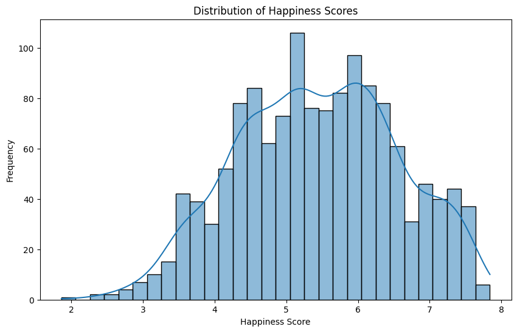

```python
# Visualizing the distribution of happiness scores
plt.figure(figsize=(10, 6))
sns.histplot(outlier_df['happiness_score'], bins=30, kde=True)
plt.title('Distribution of Happiness Scores')
plt.xlabel('Happiness Score')
plt.ylabel('Frequency')
plt.show()
```

**Counting outliers in each column**

```python
# check if values are outliers using the innerquartile range
def count_outliers(column):
      first_quartile = column.quantile(0.25)
      third_quartile = column.quantile(0.75)
      IQR = third_quartile - first_quartile
      lower_bound = first_quartile - 1.5 * IQR
      upper_bound = third_quartile + 1.5 * IQR
      outliers = (column < lower_bound) | (column > upper_bound)
      outliers_count = outliers.sum()
      return outliers_count

outlier_df.apply(count_outliers)
```

```
happiness_score                   1
gdp_per_capita                    0
social_support                   14
healthy_life_expectancy           0
freedom_to_make_life_choices     17
generosity                       50
perceptions_of_corruption       110
dtype: int64
```

**Conclusion**

**Graph** (black dots represent outliers)

Outliers can be factors that can skew our analysis and using boxplots, we investigated them to understand their impact.

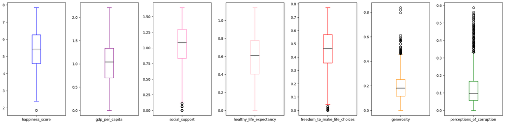

```python
# create boxplots for each column
fig, axes = plt.subplots(1, 7, figsize=(20, 5))
colors = ['blue', 'purple', 'hotpink', 'lightpink', 'red', 'darkorange', 'green']
for i, (column, color) in enumerate(zip(outlier_df.columns, colors)):
    outlier_df[column].plot(kind='box', ax=axes[i], color=dict(boxes=color, whiskers=color, medians='black', caps=color))
plt.tight_layout()
plt.show()
```

### Correlation Coefficient Matrix between happiness, gdp, and healthy life expectancy

```python
correlations = df[['happiness_score', 'gdp_per_capita', 'healthy_life_expectancy', 'social_support' ]].corr()
print(correlations)
# strong correlation between happy -> gdp
# less strong with happy -> healthy
# weak with gdp -> healhty
```

```
                         happiness_score  gdp_per_capita  \
happiness_score                 1.000000        0.723785
gdp_per_capita                  0.723785        1.000000
healthy_life_expectancy         0.682480        0.565537
social_support                  0.649844        0.524691

                         healthy_life_expectancy  social_support
happiness_score                         0.682480        0.649844
gdp_per_capita                          0.565537        0.524691
healthy_life_expectancy                 1.000000        0.561644
social_support                          0.561644        1.000000
```

**Heatmap Representing the strength of the relationship**

Here, we conducted a correlation anaylsis to see if we can identify the relationships between the happiness score and any other factors. It ultimately helped us to better understand how each factor is associated with happiness.

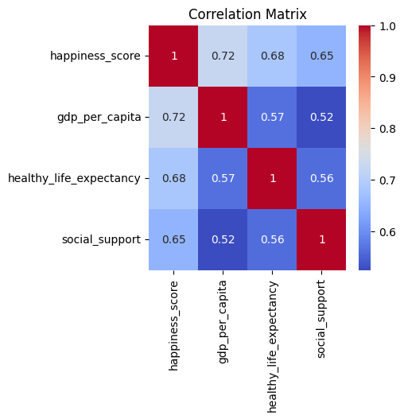

```python
plt.figure(figsize = (4,4))
sns.heatmap(correlations, annot=True, cmap='coolwarm')
plt.title('Correlation Matrix')
plt.show()
```

**Conclusion**

We found some key points:

1. There was a strong positive correlation that involvoed happiness scores and GDP per Capita, which showed that wealther countries were usually happier.
2. Social support also had a positive correlation with happiness, meaning that it is important to have community and relationships when it comes to happiness.
3. Having higher life expectancy also had a positive correlation with happiness, meaning that health and well being are also important when it comes to that factor.

In summary, in general there is a strong positive correlation between happiness score and GDP per capita (.72) and a strong positive correlation between happiness and life expectancy (.68). There is a positive correlation between GDP and life expectancy, however, it is not as strong as the others (.56). Therefore, the main factors that contribute to happiness is a high GDP per capita and health.

### ANOVA Test

Hypothesis test on whether the region of an person has a correlation with their happiness score. Assume alpha is .05

$H_{0}$: *There is no difference between any of the region means*

$H_{A}$: *There is a difference between at least one of the region means*

```python
from scipy.stats import f_oneway
unique_regions = df['region'].unique()
region_happiness = [df[df['region'] == regions]['happiness_score'] for regions in unique_regions]
anova = f_oneway(*region_happiness)
print(anova)
```

```
F_onewayResult(statistic=211.89343281575762, pvalue=1.3999866922539324e-268)
```

**Graph**

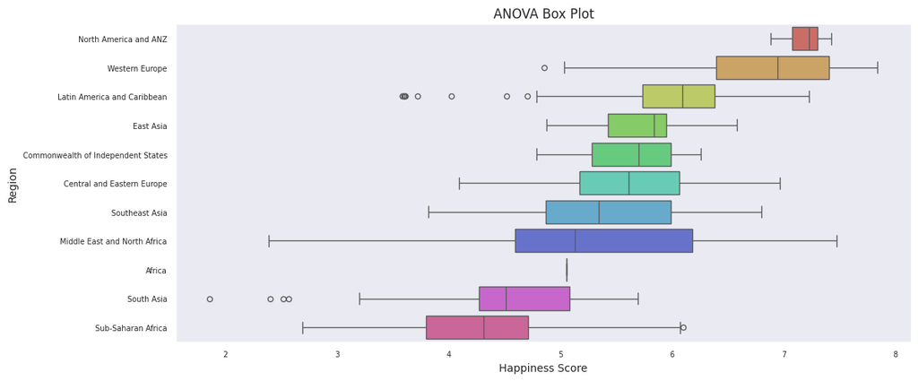

```python
# sort mean values by descending order
mean_vals = df.groupby('region')['happiness_score'].mean().sort_values(ascending = False).index
sns.set(style="dark")
palette = sns.color_palette("hls", 11)
plt.figure(figsize=(12,5))
sns.set_context("paper", font_scale=0.8)
sns.boxplot(x = 'happiness_score', y = 'region', data = df, palette = palette, orient = 'h', order = mean_vals)
plt.title("ANOVA Box Plot", fontsize = 12)
plt.xlabel("Happiness Score", fontsize = 10)
plt.ylabel("Region", fontsize = 10)
plt.tight_layout()
plt.show()
```

## **Primary Analysis**

**Overview:**

We also decided to remove the column 'region' because it was simply too much data to handle. Even if we batched the data to train it or made a mini data set, the model would get stuck in training. We did still want to invlove the location of the happiness score, so we kept the country. This was a lot of data itself as we had to one hot encode it, but it was managable.

### Cleaning Data

```python
# Split the data
X = df.drop(columns=['happiness_score', 'region'])
Y = df['happiness_score']

original_cols = X.columns

one_hot_cols = ['country']
X_encoded = pd.get_dummies(X, columns = one_hot_cols, drop_first = True)


X_train, X_test, Y_train, Y_test = train_test_split(X_encoded, Y, test_size=0.2, random_state=42)

# Standardize the features so that we can compare their relative importances on a common scale
scaler = StandardScaler()
X_train = scaler.fit_transform(X_train)
X_test = scaler.transform(X_test)
```

More on how StandardScalar() works: https://scikit-learn.org/stable/modules/generated/sklearn.preprocessing.StandardScaler.html

### Create Model and Make Initial Predictions

```python
# Create the model and fit it to the training data
model = ElasticNet(alpha=0.01, random_state=42)
model.fit(X_train, Y_train)

# Make predictions on the training and testing data
Y_train_pred = model.predict(X_train)
Y_test_pred = model.predict(X_test)

# Compare predictions to actual values
coefficient_values = model.coef_
column_names = X_encoded.columns
df_coefficients = pd.DataFrame(data={'Coefficient':coefficient_values, 'Feature':column_names})

# Add up all the countries
filtered = df_coefficients[~df_coefficients['Feature'].isin(original_cols)]
excluded = df_coefficients[df_coefficients['Feature'].isin(original_cols)]

sum_countries = filtered["Coefficient"].abs().sum()
data = {'Coefficient' : [sum_countries] + excluded['Coefficient'].tolist(),
                    'Feature' : ["country"] + excluded['Feature'].tolist()}

df_coefficients_2 = pd.DataFrame(data)

# A higher magnitude of a standardized coefficient indicates that the feature it corresponds to has a stronger effect on
# the target variable relative to other features.
df_coefficients_2 = df_coefficients_2.sort_values(by=['Coefficient'], ascending=False)
df_coefficients_2.head()
```

|  | Coefficient | Feature |
| --- | --- | --- |
| 0 | 4.205322 | country |
| 1 | 0.295564 | gdp_per_capita |
| 4 | 0.294100 | freedom_to_make_life_choices |
| 3 | 0.276913 | healthy_life_expectancy |
| 2 | 0.130662 | social_support |

The prediction above clearly thinks that country matters by far the most on happiness score. This is followed by gpd per capita, freedom to make life choices, and healthy life expectancy. The country has extreme influence on happiness level, and this score is the overall magnitude because it is the sum of the absolute values of each country.

ElasticNet explained: https://machinelearningcompass.com/machine_learning_models/elastic_net_regression/

### Check Accuracy of Model and Make Adjustments

```python
# See how different different degrees change the performance of the model

for degree in range(1, 3):
  # Create model and make initial predictions
  # Introduced tolerance because of convergance
  model = make_pipeline(PolynomialFeatures(degree=degree), ElasticNet(alpha=0.01, max_iter=10000, tol = 1e-3))
  model.fit(X_train, Y_train)
  Y_train_pred = model.predict(X_train)
  Y_test_pred = model.predict(X_test)
  # Calculate MSE and R^2 for the dataset
  mse_train = mean_squared_error(Y_train, Y_train_pred)
  mse_test = mean_squared_error(Y_test, Y_test_pred)
  r2_train = r2_score(Y_train, Y_train_pred)
  r2_test = r2_score(Y_test, Y_test_pred)
  results = ({
        "MSE Train": mse_train,
        "MSE Test": mse_test,
        "R2 Train": r2_train,
        "R2 Test": r2_test
    })
  # Print results
  print(f"DEGREE {degree}:")
  print(f"  MSE Train: {results['MSE Train']:.4f}")
  print(f"  MSE Test: {results['MSE Test']:.4f}")
  print(f"  R2 Train: {results['R2 Train']:.4f}")
  print(f"  R2 Test: {results['R2 Test']:.4f}")
  print()


# Create final model using degree 2
# Our model certainly isn't perfect, but it does a good job of making predictions
```

```
DEGREE 1:
  MSE Train: 0.0903
  MSE Test: 0.1095
  R2 Train: 0.9279
  R2 Test: 0.9107

DEGREE 2:
  MSE Train: 0.0243
  MSE Test: 0.0828
  R2 Train: 0.9806
  R2 Test: 0.9324
```

**Takeaways:** The model that we chose has a MSE of 0.0828 and R2 score of 0.9324 for the testing data.

For both degrees 1 and 2, our outputs are pretty good for both MSE and R2 score. In degree 2, MSE lowers and our R2 score increases, signifying that it is a better model. This is true for both the training and testing data.

Because of this, we chose to use degree 2 for our final model.

**Assessment of Model Performance**

*As a reference:*

- r2 = 0: the model doesn't explain any of the variance in the dependent variable (happiness_score)
- r2 = 1: the model explains all of the variance in the dependent variable (happiness_score)
- 'low' MSE (close to 0): indicates that the model's predictions are close to the actual values
- 'high' MSE: indicates that the model's predictions are far from the actual values
- Note: what 'low' and 'high' mean in MSE is completely based on the context of the data

More on MSE and R2 scores: https://www.bmc.com/blogs/mean-squared-error-r2-and-variance-in-regression-analysis/

## **Visualization**

Summing the coefficents to create a heatmap for each degree, and visualizing the model.

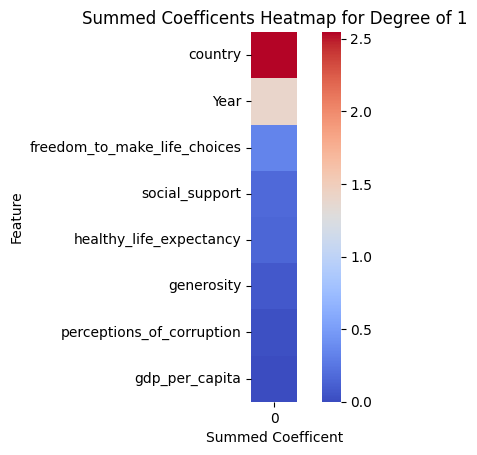

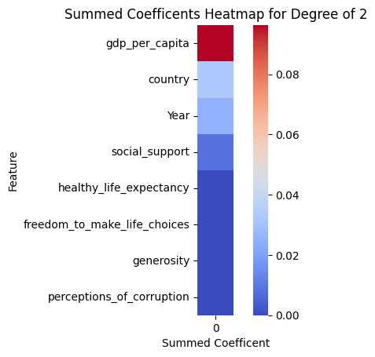

```python
# Compare predictions to actual values

coefficient_values = model.named_steps['elasticnet'].coef_
feature_names = model.named_steps['polynomialfeatures'].get_feature_names_out(input_features = column_names)

coefficients = { degree: {column : 0 for column in original_cols} for degree in range(1,3) }

# Function to determine what degree each feature is & return editied feature name
nums = ['2']
def splitter(list, coefs):
  index = 0
  for item in list:
    coef = coefs[index]
    num = 1
    sublist = item.split(' ')
    for subitem in sublist:
      if subitem == 'gdp_per_capita':
        num = 2
      if 'country_' in subitem:
        coefficients[num]['country'] +=  abs(coef)
      elif subitem in original_cols:
        coefficients[num][subitem] +=  abs(coef)

    index += 1

splitter(feature_names, coefficient_values)


# Heatmap for degree 1 and 2
for degree, coef in coefficients.items():
  # Sort the dict (converts it to a list)
  coef = sorted(coef.items(), key=lambda x: x[1], reverse=True)
  # Convert to dataframe
  sorted_columns = [tup[0] for tup in coef]
  sorted_coefs =   [tup[1] for tup in coef]
  temp_df = pd.DataFrame(sorted_coefs, index = sorted_columns)
  # Create heatmap for the current degree
  plt.figure()
  plt.title(f"Summed Coefficents Heatmap for Degree of {degree}" )
  sns.heatmap(temp_df, square = True, annot = False, cmap = 'coolwarm')
  plt.ylabel("Feature")
  plt.xlabel("Summed Coefficent")
  plt.show()
  print()
```

Higher degree terms can model more complex relationships but have lower coefficients than lower degree terms which often capture more straightforward relationships. With this in mind, these heatmaps give us an understanding of the relative importance of each feature when predicting happiness_score at different degrees (by looking at the magnitude of each feature's coefficient).

Country seems to be (by far) the most influential feature at degree 1, with Year and freedom to make life choices after. Year was very surprising to see so high up on the heatmap, as it was not on the initial prediction of the coefficients.

For degree 2, gdp per capita is by far the most important, followed by country and then year. We were expecting healthy life expectancy to be more important than the year, so both of these heatmaps surprised us.

**Actual vs Predicted**

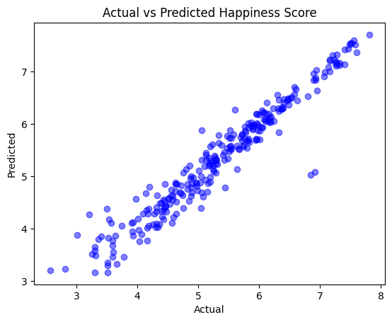

```python
plt.figure()
plt.scatter(Y_test, Y_test_pred, color = 'blue', alpha = .5)
plt.xlabel("Actual")
plt.ylabel("Predicted")
plt.title("Actual vs Predicted Happiness Score")
plt.show()
```

To read this plot, the ideal line would be y=x. This plot is pretty close to being that, so this means that the predicted scores are pretty similar to the real ones. The scores seem to increase in accuracy as the line goes up and to the right, and there are way more outliers near the bottom. Although the line is thick, I think this visualization signifies that the model was not too shabby.

**Partial Dependence Display**

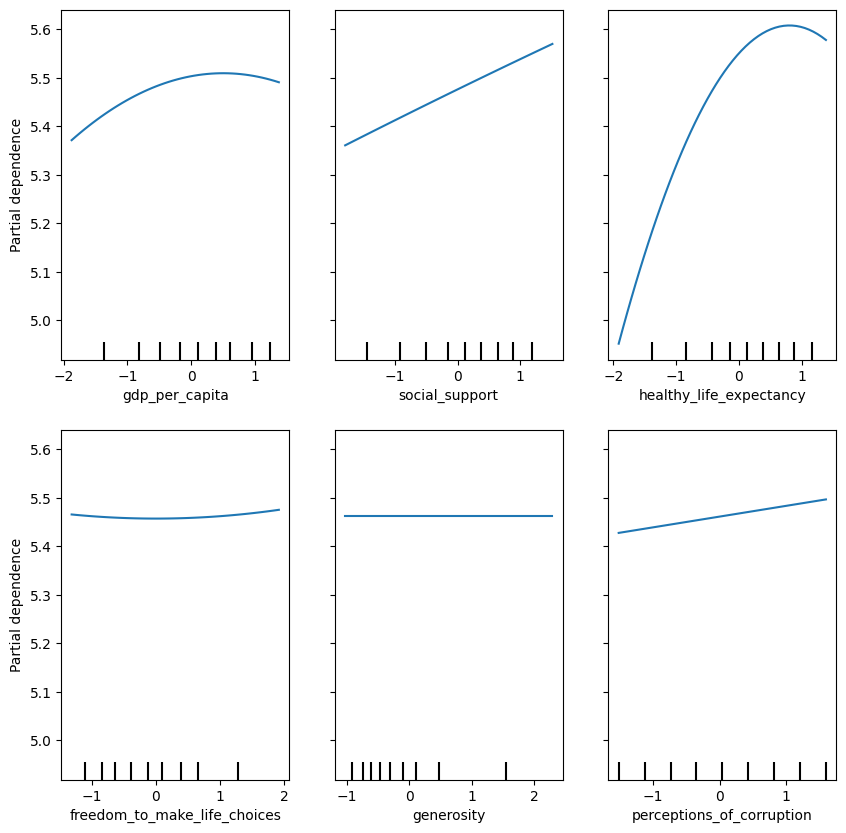

```python
plt, ax = plt.subplots(figsize = (10,10))
PartialDependenceDisplay.from_estimator(
    model, X_train, [1, 2, 3, 4, 5, 6], feature_names = feature_names, grid_resolution=50, ax = ax
)
plt.show()
```

More on these plots: https://medium.com/@kumar9059300448/partial-dependence-plots-f1464ce66f1a

## Insights and Conclusions

**Summary of our findings:**

The analysis for the World Happiness Report data from 2015 to 2023 showed us important factors that influence happiness.

The main goal of this study was to examine how different factors impact a countries' happiness score. We did this by using different correlation analysis techniques such as testing for outliers, comparing the correlation between different factors, and the ANOVA Test. A linear model using Elastic Net reguliarization was also built to predict happiness scores based on the various opinions of the citizen.

The most defining variable on happiness scores were what country each person was from, followed by gdp per capita, what year it is, and freedom to make life choices. These are defining factors in what "world" a country can be consitered. Richer countries with more freedom have a much better chance at having a higher happiness score. I believe that we would be able to predict happiness score based off of just the statistics of a country without knowing which country it is, mainly based off of the factors listed above.

**Policy Implications:**

Overall, our findings could be used in many different ways to improve the general happiness of the global population. If governemnts make poilicies that boost economic growth and increase GDP per capita, it can increase happiness. Government policymakers can use data collected from our correlation analysis to determine that GDP per capita has one of the highest positive correlations with happiness. They can use that to focus on becoming more wealthy by promoting economic growth. They can also see that social support networks also enhance happinesss and even minor policies that are aimed to improve community support, social services, and mental health would be key to improving overall happiness. Some other key aspects that could also be improved would be healthcare and overall improving health expectancy. A lot of the other factors can intertwine with each other in a general aspect as well. Such as if there is great economic stimulation, it could in turn increase multiple other factors such as healthy life expectancy from increased wealth and access to medicine and hospitals, as well as social support.

**Future Research:**

**Areas for Improvement:**

In the future, we can find a dataset that contains additional variables such as economic growth and environmental quality. This would be interesting because economic growth can positive impact a country but also cause a negative impact when the income disparity increases. Since the relationship economic growth has with happiness is multifaceted; it can overall be positively improved, or lead to increased stress and social inequality which makes it interesting when compared to the other categories. Additionally, incorporating environmental quality is an extremely important factor which should be monitored since lower pollution, better air, etc. are huge factors in everyday life. These additional factors can potential explain why the happiness varies drastically from some countries like North Africa and Southeast Asia (shown in the ANOVA Box Plot), while countries like North America has a very small variation. Neural networks can also be applied to our model because it would be able to capture complex relationships that the linear model cannot. This will lead to the model having a better prediction accuracy and new conclusions.